# NBIS Report: SMS_6112_Healthy_aging_in_Myotis_brandtii

25-Oct-2022

**NBIS ID:** SMS-6112  
**Report Version:** 0.7  
**Request by:** Mattias Westman (mattias.westman@ki.se)  
**Principal Investigator:** Carl-Johan Sundberg (carl.j.sundberg@ki.se)  
**Organisation:** KI  
**NBIS Staff:** Juliana Assis (juliana.assis@nbis.se)

## 0.1 Methods

### 0.1.1 Data

- Data location cd /proj/snic2022-22-672
- Uppmax project ID

SNIC 2022/23-355 SNIC Small Storage  
SNIC 2022/22-672 SNIC Small Compute

- Reference data used NCBI Myotis brandtii Annotation Release 101

# 1 Tools

nfcore-rnaseq Trinity

|  | sample_id | bat | organ |
| --- | --- | --- | --- |
| P24120_101_S308_L003_quant.sf | P24120_101 | Bat_1 | Skeletal muscle |
| P24120_102_S309_L003_quant.sf | P24120_102 | Bat_1 | Kidney |
| P24120_104_S310_L003_quant.sf | P24120_104 | Bat_2 | Skeletal muscle |
| P24120_105_S311_L003_quant.sf | P24120_105 | Bat_2 | Kidney |
| P24120_106_S312_L003_quant.sf | P24120_106 | Bat_2 | Intestine |

```r
# PCA

#head(assay(exp, "counts"))
shapiro.test(as.numeric(assay(dds[1,])))
```

```
##
##  Shapiro-Wilk normality test
##
## data:  as.numeric(assay(dds[1, ]))
## W = 0.60392, p-value = 0.0007067
```

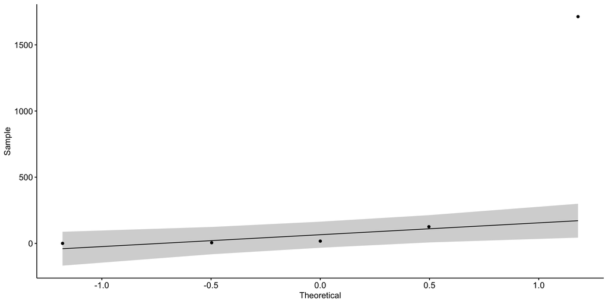

```r
ggpubr::ggqqplot(as.numeric(assay(dds[1,])))
```

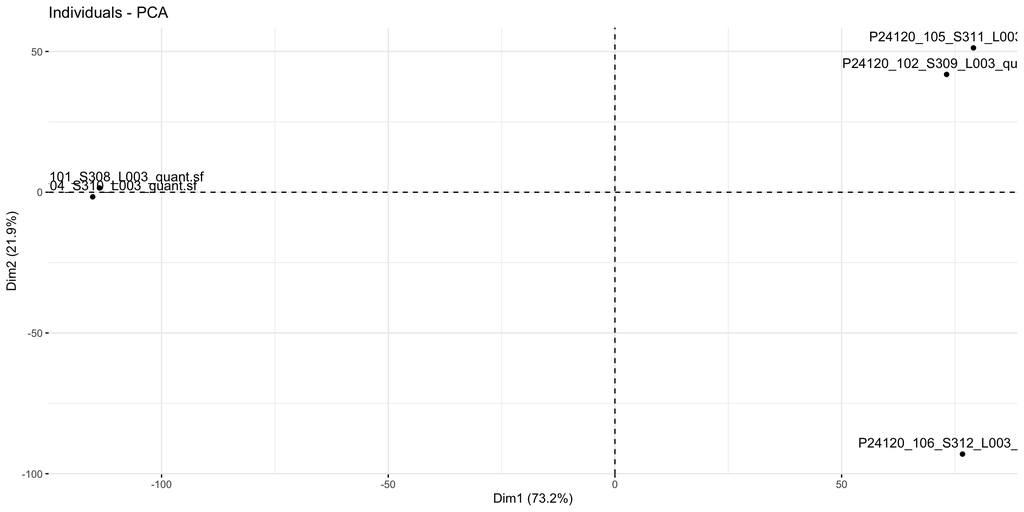

PCA plot of the first 2 principal components. Calculated using the 500 most variable genes.

```r
data_norm <- vst(assay(dds))
#dds <- DESeq(dds)
var_genes <- apply(data_norm, 1, var)

# Get the gene names for the top 500 most variable genes
select_var <- names(sort(var_genes, decreasing=TRUE))[1:500]
data_norm_var <- data_norm[select_var,]

# perform PCA
res.pca <- PCA(t(data_norm_var), scale.unit = FALSE, graph = FALSE)
# visualize
a <- fviz_pca_ind(res.pca)
cowplot::plot_grid(a)
```

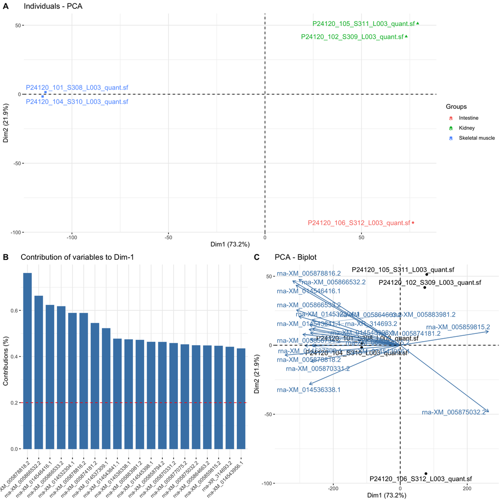

group is distributed along PC1. (A) PCA plot with samples coloured according to groups (B) Top 20 genes contributing to PC1. (C) Biplot showing the correlations among the top 20 genes and the PCs.

```r
b <- fviz_pca_ind(res.pca,
                repel = TRUE,
                habillage =factor(colData(dds)[,"organ"]),
                invisible="quali")
#ggsave("./PCA/groupPCA.pdf", b)
c <- fviz_contrib(res.pca, choice = "var", axes = 1, top = 20)
#ggsave("./PCA/Barplot_Top20_PC1.pdf", c)
e <- fviz_pca_biplot(res.pca,
                repel = TRUE,
                select.var =list(name = rownames(head(res.pca$var$contrib[order(res.pca$var$contrib[,1], decreasing = TRUE),], 20))),
                invisible="quali")
#ggsave("./PCA/Biplot_Top20_PC1.pdf", e)
bottom_row <- cowplot::plot_grid(c,e, labels = c("B", "C"))
cowplot::plot_grid(b,bottom_row, labels = c("A", ""), ncol = 1)
```

These type of PC analyses are not a real alternative for a proper statistically supported differential expression analysis, but gives an idea of the structure in the data. What drives the biggest differences among the samples?

```r
library(rafalib)
#PC <-  prcomp( t( Znorm[ top_var, ]) ) #Method1

leading_genes <- res.pca$ind$contrib
#res.pca$ind$contrib
head(leading_genes)
```

```
##                                  Dim.1       Dim.2       Dim.3      Dim.4
## P24120_101_S308_L003_quant.sf 29.59655  0.01789442 16.86930603 33.5162538
## P24120_102_S309_L003_quant.sf 12.25238 13.43149248 34.69919517 19.6169294
## P24120_104_S310_L003_quant.sf 30.38010  0.02042740 18.08159090 31.5178805
## P24120_105_S311_L003_quant.sf 14.31737 20.16611027 30.29143212 15.2250865
## P24120_106_S312_L003_quant.sf 13.45360 66.36407543  0.05847579  0.1238498
```

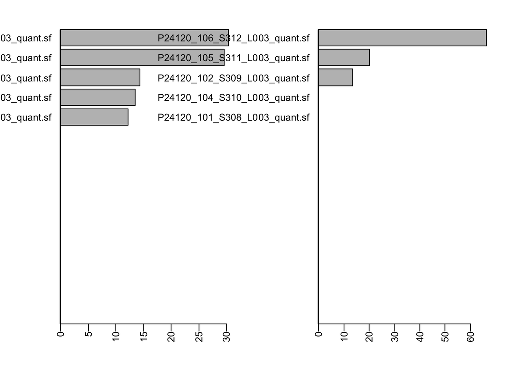

```r
leading_PC1 <- sort(leading_genes[,1],decreasing=T)
leading_PC2 <- sort(leading_genes[,2],decreasing=T)

{
  mypar(1,2,mar=c(3,4,2,2))
  barplot(leading_PC1[15:1],las=2,horiz=T,cex.names=.8,cex.axis=0.8,yaxs="i")
  abline(v=0,lwd=2)
  barplot(leading_PC2[15:1],las=2,horiz=T,cex.names=.8,cex.axis=0.8,yaxs="i")
  abline(v=0,lwd=2)
}
```

```r
d <- DESeq2::estimateSizeFactors(dds,type="ratio")
```

```
##   Note: levels of factors in the design contain characters other than
##   letters, numbers, '_' and '.'. It is recommended (but not required) to use
##   only letters, numbers, and delimiters '_' or '.', as these are safe characters
##   for column names in R. [This is a message, not a warning or an error]
```

```
## using 'avgTxLength' from assays(dds), correcting for library size
```

```r
d <- DESeq2::estimateDispersions(d)
```

```
## -- note: fitType='parametric', but the dispersion trend was not well captured by the
##    function: y = a/x + b, and a local regression fit was automatically substituted.
##    specify fitType='local' or 'mean' to avoid this message next time.
```

[output not shown]

[output not shown]

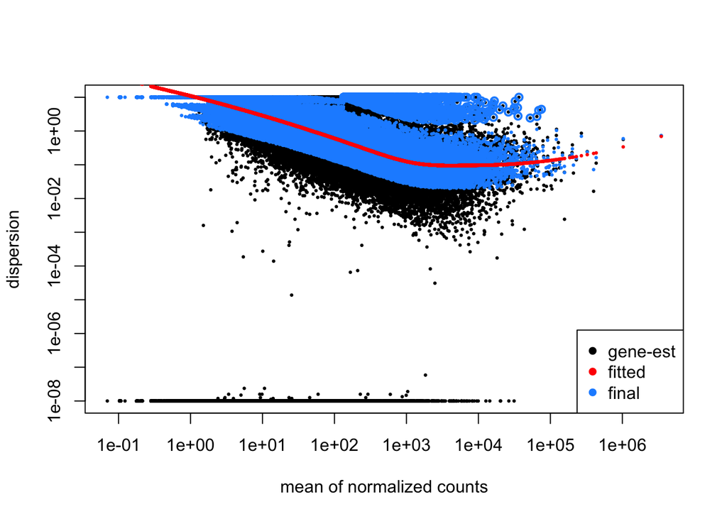

```r
plotDispEsts(d)
```

```r
library("pheatmap")
vsd <- vst(dds, blind=FALSE)
```

```
##   Note: levels of factors in the design contain characters other than
##   letters, numbers, '_' and '.'. It is recommended (but not required) to use
##   only letters, numbers, and delimiters '_' or '.', as these are safe characters
##   for column names in R. [This is a message, not a warning or an error]
```

```
## using 'avgTxLength' from assays(dds), correcting for library size
```

```
## -- note: fitType='parametric', but the dispersion trend was not well captured by the
##    function: y = a/x + b, and a local regression fit was automatically substituted.
##    specify fitType='local' or 'mean' to avoid this message next time.
```

```r
rld <- rlog(dds, blind=FALSE)
```

[output not shown]

```
## using 'avgTxLength' from assays(dds), correcting for library size
```

```
## -- note: fitType='parametric', but the dispersion trend was not well captured by the
##    function: y = a/x + b, and a local regression fit was automatically substituted.
##    specify fitType='local' or 'mean' to avoid this message next time.
```

```r
head(assay(vsd), 3)
```

```
##                    P24120_101_S308_L003_quant.sf P24120_102_S309_L003_quant.sf
## rna-XM_014543571.1                      5.456659                      7.550154
## rna-XM_014547455.1                      5.456659                     10.842909
## rna-XM_014547511.1                      5.456659                      5.456659
##                    P24120_104_S310_L003_quant.sf P24120_105_S311_L003_quant.sf
## rna-XM_014543571.1                      6.782295                      9.634043
## rna-XM_014547455.1                      5.456659                     11.253098
## rna-XM_014547511.1                      5.456659                      5.456659
##                    P24120_106_S312_L003_quant.sf
## rna-XM_014543571.1                      6.420627
## rna-XM_014547455.1                     12.593944
## rna-XM_014547511.1                      5.456659
```

```r
# this gives log2(n + 1)
ntd <- normTransform(dds)
```

[output not shown]

```
## using 'avgTxLength' from assays(dds), correcting for library size
```

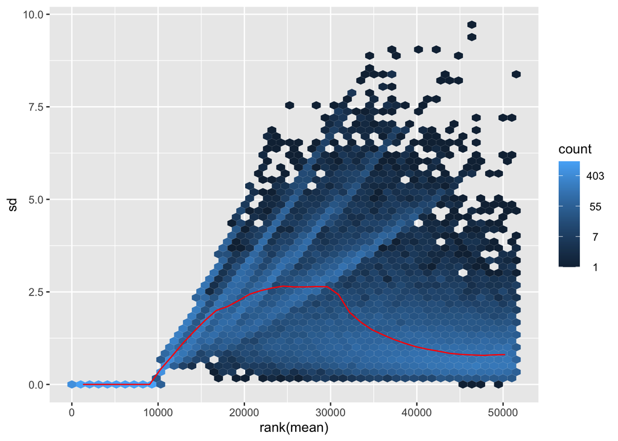

```r
library("vsn")
meanSdPlot(assay(ntd))
```

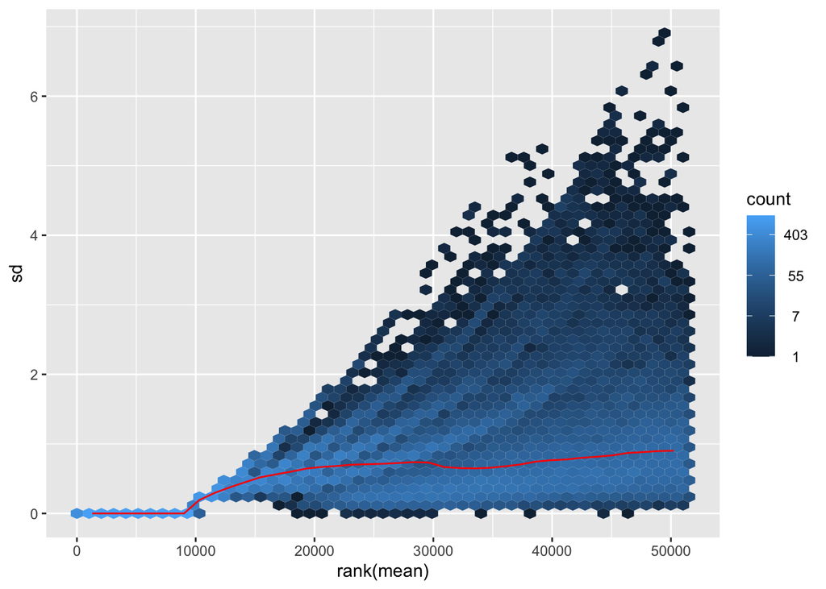

```r
meanSdPlot(assay(vsd))
```

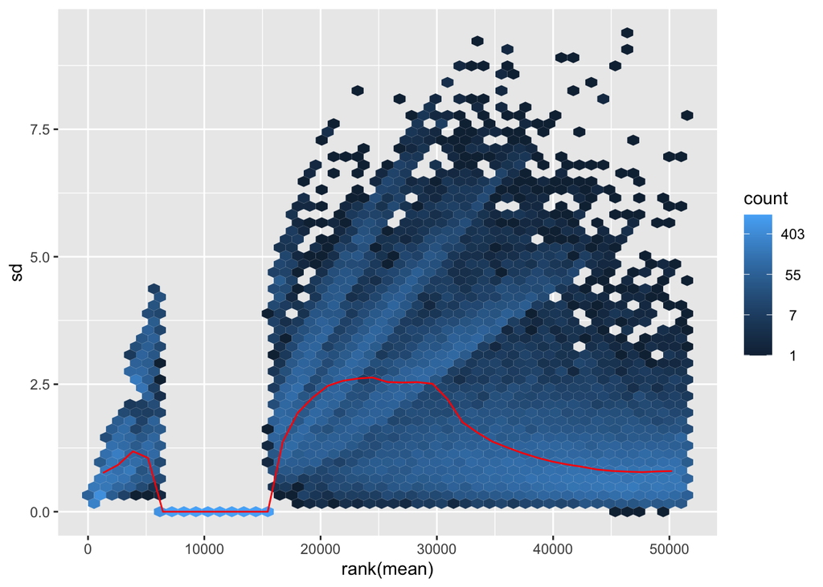

```r
meanSdPlot(assay(rld))
```

```r
#####
nm <- assays(dds)[["avgTxLength"]]
#sf <- estimateSizeFactorsForMatrix(counts(dds), normMatrix=nm)


diagdds = dds
# calculate geometric means prior to estimate size factors
gm_mean = function(x, na.rm=TRUE){
  exp(sum(log(x[x > 0]), na.rm=na.rm) / length(x))
}
geoMeans = apply(counts(diagdds), 1, gm_mean)
diagdds = estimateSizeFactors(diagdds, geoMeans = geoMeans)
```

```
##   Note: levels of factors in the design contain characters other than
##   letters, numbers, '_' and '.'. It is recommended (but not required) to use
##   only letters, numbers, and delimiters '_' or '.', as these are safe characters
##   for column names in R. [This is a message, not a warning or an error]
## using 'avgTxLength' from assays(dds), correcting for library size
```

```r
diagdds = DESeq(diagdds, fitType="local")
```

[output not shown]

[output not shown]

```r
#
resultsNames(diagdds) # lists the coefficients
```

```
## [1] "Intercept"                          "organ_Kidney_vs_Intestine"
## [3] "organ_Skeletal.muscle_vs_Intestine"
```

```r
ddsCustom <- diagdds
useForMedian <- mcols(ddsCustom)$dispGeneEst > 1e-7
medianDisp <- median(mcols(ddsCustom)$dispGeneEst[useForMedian],
                     na.rm=TRUE)
dispersionFunction(ddsCustom) <- function(mu) medianDisp
```

[output not shown]

```r
ddsCustom <- estimateDispersionsMAP(ddsCustom)
```

```
## found already estimated dispersions, removing these
```

[output not shown]

[output not shown]

```
## Also defined by 'ggbio'
```

[output not shown]

```
## Also defined by 'ggbio'
```

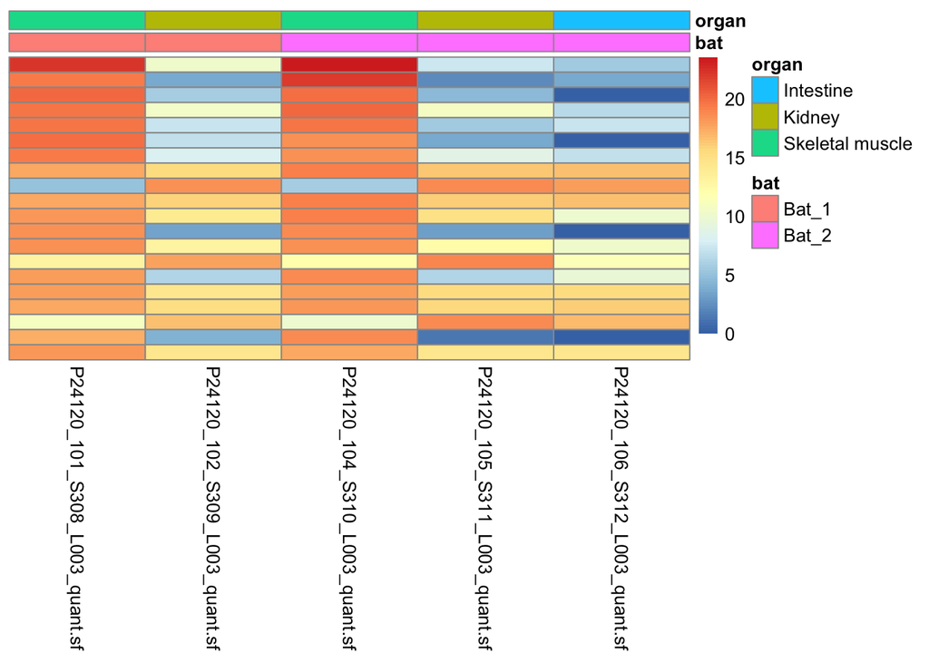

```r
###

select <- order(rowMeans(counts(diagdds,normalized=TRUE)),
                decreasing=TRUE)[1:20]

df <- as.data.frame(colData(diagdds)[,c("bat","organ")])

pheatmap(assay(ntd)[select,], cluster_rows=FALSE, show_rownames=FALSE,
         cluster_cols=FALSE, annotation_col=df)
```

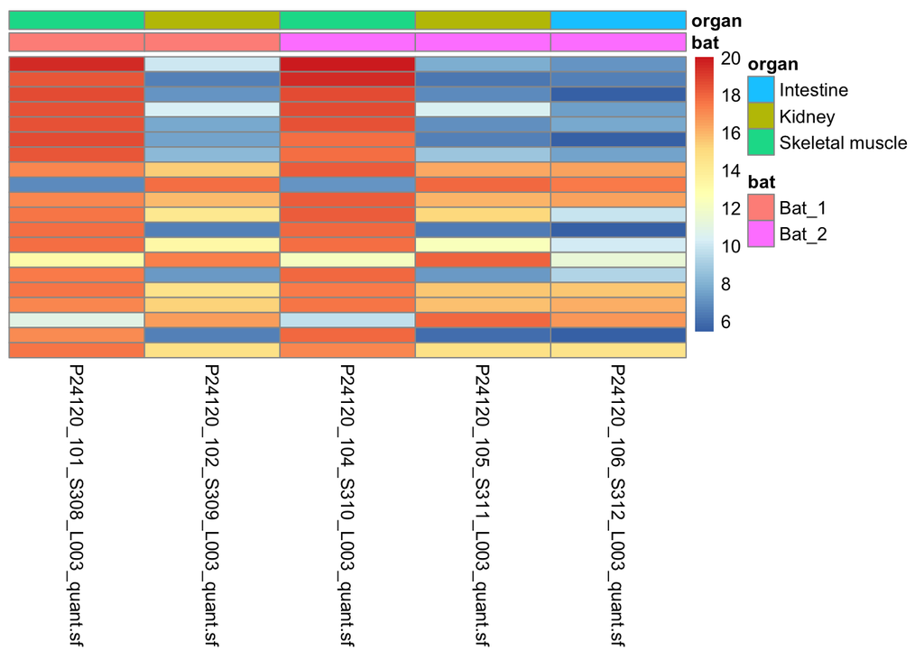

```r
pheatmap(assay(vsd)[select,], cluster_rows=FALSE, show_rownames=FALSE, cluster_cols=FALSE, annotation_col=df)
```

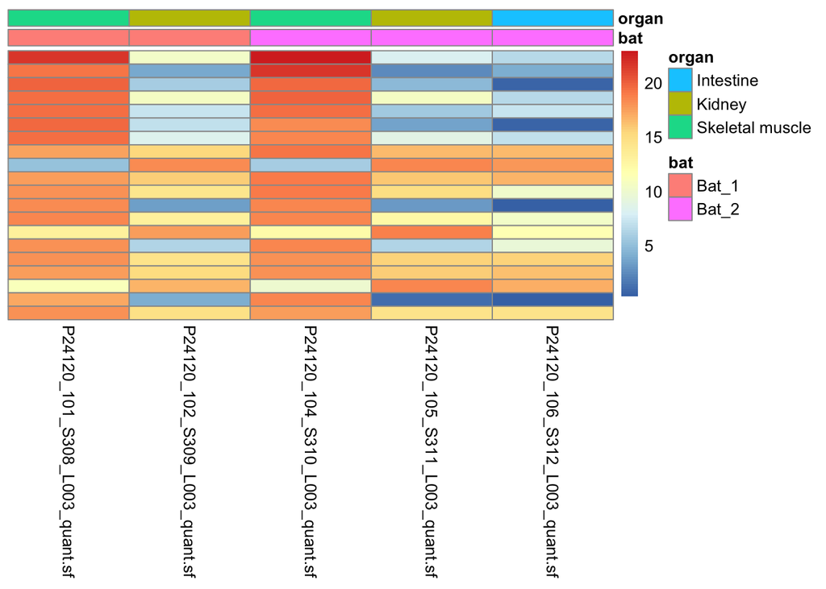

```r
pheatmap(assay(rld)[select,], cluster_rows=FALSE, show_rownames=FALSE, cluster_cols=FALSE, annotation_col=df)
```

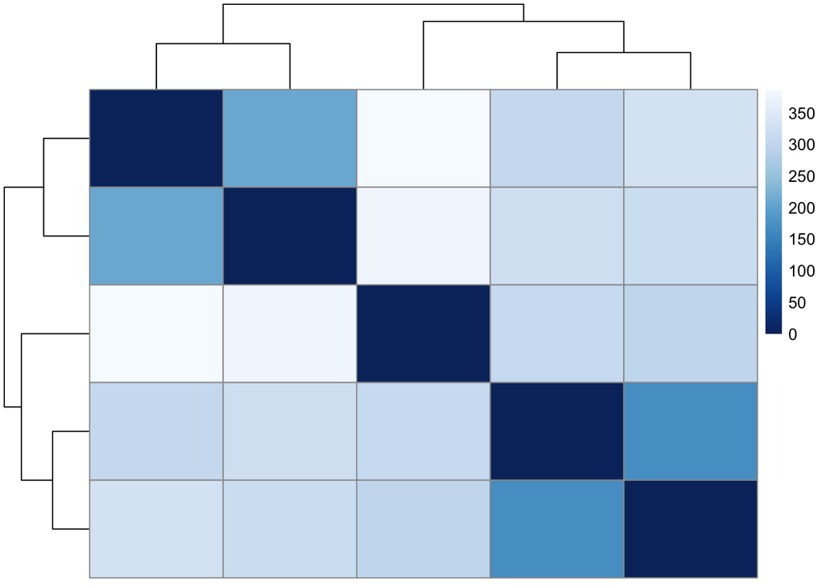

```r
sampleDists <- dist(t(assay(vsd)))
library("RColorBrewer")
sampleDistMatrix <- as.matrix(sampleDists)
rownames(sampleDistMatrix) <- paste(vsd$condition, vsd$type, sep="-")
colnames(sampleDistMatrix) <- NULL
colors <- colorRampPalette( rev(brewer.pal(9, "Blues")) )(255)
pheatmap(sampleDistMatrix,
         clustering_distance_rows=sampleDists,
         clustering_distance_cols=sampleDists,
         col=colors)
```

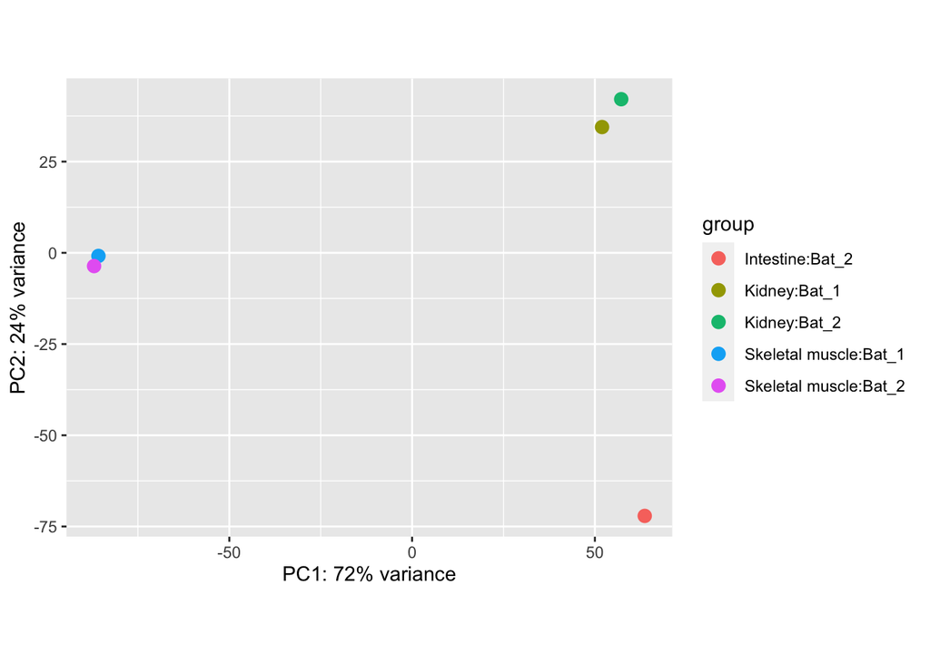

```r
plotPCA(vsd, intgroup=c("organ", "bat"))
```

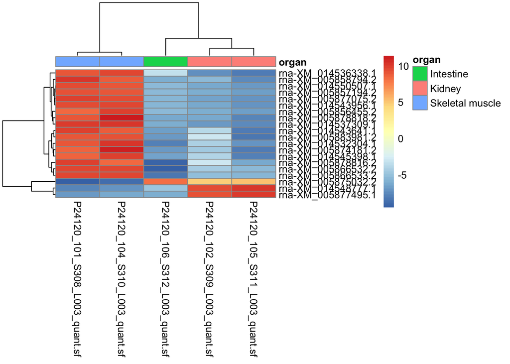

```r
topVarGenes <- head(order(rowVars(assay(rld)), decreasing = TRUE), 20)
mat  <- assay(rld)[ topVarGenes, ]
mat  <- mat - rowMeans(mat)
anno <- as.data.frame(colData(rld)[c("organ")])
pheatmap(mat, annotation_col = anno)
```